# Bazinga Movies

## About this Project

The idea of the App is:

*“Search and seek information about world cinema using the TMDB api ([tmdb](https://developers.themoviedb.org/3))”.*

## Why?

This project is part of my personal portfolio, so, I’ll be happy if you could provide me any feedback about the project, code, structure or anything that you can report that could make me a better developer!

Email-me: harrisonhenrisn@gmail.com

Connect with me at [LinkedIn](https://linkedin.com/in/harrison-henri-dos-santos-nascimento-a6ba33112).

Also, you can use this Project as you wish, be for study, be for make improvements or earn money with it!

It’s free!

## Functionalities

- Login with Google account

[figure not shown]

- Check the movies recommended for you

[figure not shown]

The recommendation system is based on the Person Correlation Score (see more details in https://becominghuman.ai/introduction-to-recommendation-system-in-javascript-74209c7ff2f7):

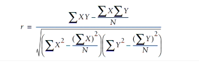

- Search new movies

[figure not shown]

- See movies details and rating

[figure not shown]

## Install

Clone the repo using

```
$ git clone https://github.com/HarrisonHenri/Bazinga-Movies
```

```
$ cd Bazinga-Movies
```

Install all the required dependencies of backend using (backend directory)

```
$ npm install
```

Install all the required dependencies of frontend using (frontend directory)

```
$ npm install
```

In backend directory, execute

```
$ npm run dev
```

## Built With

- [Redux](https://redux.js.org/) - React State Manager
- [Router](https://github.com/ReactTraining/react-router) - Routers
- [Axios](https://github.com/axios/axios) - HTTP Client
- [Express](https://github.com/expressjs/express)
- [Mongoose](https://github.com/Automattic/mongoose) - ODM
- [Oauth20](https://github.com/jaredhanson/passport-google-oauth2) - Auth Client
- [ESlint](https://eslint.org/) - Linter
- [Prettier](https://prettier.io/) - Code Formatter
- [Babel](https://babeljs.io/) - JavaScript Compiler
- [Styled-Components](https://www.styled-components.com/) - Styles
- [Webpack](https://github.com/webpack/webpack) - Bundler
- [Toastify](https://github.com/fkhadra/react-toastify) - UI notifications
- [Skeleton Screens](https://github.com/ToddWebDev/react-loading-skeleton) - Skeleton
- [Transitions](https://github.com/reactjs/react-transition-group) - CSS Transitions

## Contributing

You can send how many PR’s do you want, I’ll be glad to analyse and accept them! And if you have any question about the project…

Email-me: harrisonhenrisn@gmail.com

Connect with me at [LinkedIn](https://linkedin.com/in/harrison-henri-dos-santos-nascimento-a6ba33112).

Thank you!